# Order Statistics

Ty Painter

November 04, 2020

In this blog post I will analyze the variation among different quantiles of a continuous distribution.

## 0.1 Background

The median of any distribtution has a degree of uncertainty because the sample size is finite and the distribution is generally unknown. It is important to display the degree of uncertainty of all analysis involving the median of quantiles of a distribution.

# 1 Methods

## 1.1 Question 1

Begin with the median from a sample of N = 200 from the standard normal distribution. Write an R function that is the density function for the median in this sample. Note that the 100th order statistic is approximately the median, and use the order statistic formula discussed in class. Generate a plot of the function.

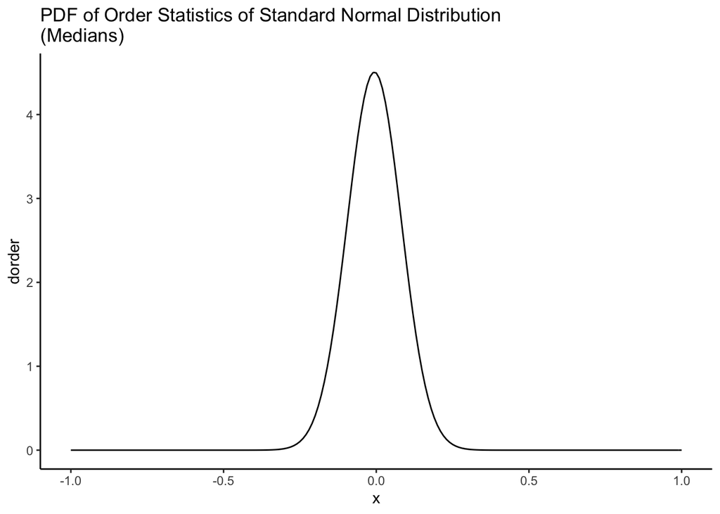

```r
dorder <- function(x,n,k=n/2){ # k defaults to the median
  k*
  choose(n,k)*
  (pnorm(x))^(k-1)*
  (1-pnorm(x))^(n-k)*
  dnorm(x)
}
library(tidyverse)
xvalues = seq(-1, 1, .01)

df1 <- data.frame(x = xvalues, dorder = dorder(xvalues, 200))
ggplot(df1, aes(x = x, y = dorder)) +
  geom_line() +
  theme_classic() +
  labs(title = "PDF of Order Statistics of Standard Normal Distribution
(Medians)")
```

In the normal distribution above, you can see how condensed the PDF is. This is because the the sample size is 200, so the larger the sample size, the more condensed the PDF will be.

## 1.2 Question 2

Write an R function that is the probability function for the median in this sample. Use the order statistic formula discussed in class. Generate a plot of the function.

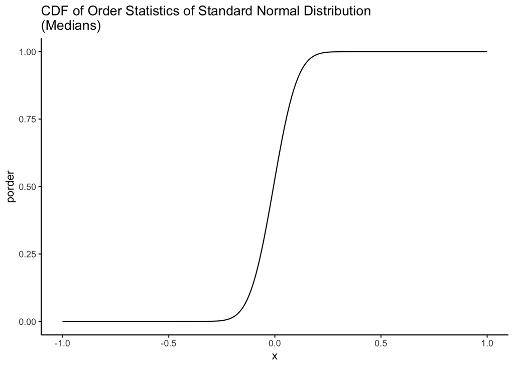

```r
porder <- function(x,n,k=n/2){ # k defaults to the median
  pbinom(k-1,
         n,
         pnorm(x,0,1),
         lower.tail = FALSE)
}
df2 <- data.frame(x = xvalues, porder = porder(xvalues, 200))
ggplot(df2, aes(x = x, y = porder)) +
  geom_line() +
  theme_classic() +
  labs(title = "CDF of Order Statistics of Standard Normal Distribution
(Medians)")
```

The CDF above will also follow the PDF as the number of samples increases, the more condensed the CDF will be.

## 1.3 Question 3

Write an R function that is the quantile function for the median in this sample. (You have several options for how to write this function.) Generate a plot of the function.

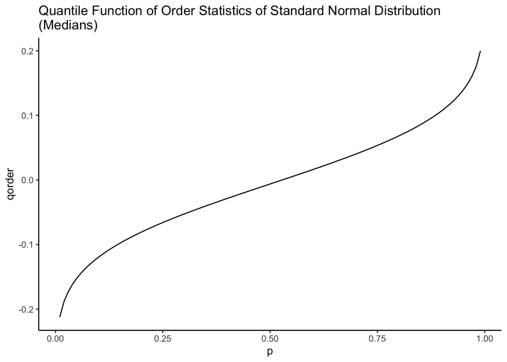

```r
qorder <- function(p,n,k=n/2) { # k defaults to the median
  out <- p
  for(i in seq_along(p)){
    out[i] <- uniroot(function(x) {porder(x,n,k) - p[i]}, c(-100,100))$root
  }
  out
}

pvalues = seq(.01,.99,.01)
df3 <- data.frame(p = pvalues, qorder = qorder(pvalues,200))
ggplot(df3, aes(x = p, y = qorder)) +
  geom_line() +
  theme_classic() +
  labs(title = "Quantile Function of Order Statistics of Standard Normal Distribution
(Medians)")
```

The quantile function above acts similar to the CDF and PDF graphs except the graph will condense vertically towards 0 along the y-axis as opposed to the x-axis.

## 1.4 Question 4

Simulate the sampling distribution for the median. Create a plot of the empirical CDF (ECDF). Overlay the plot of the ECDF with a plot of the CDF.

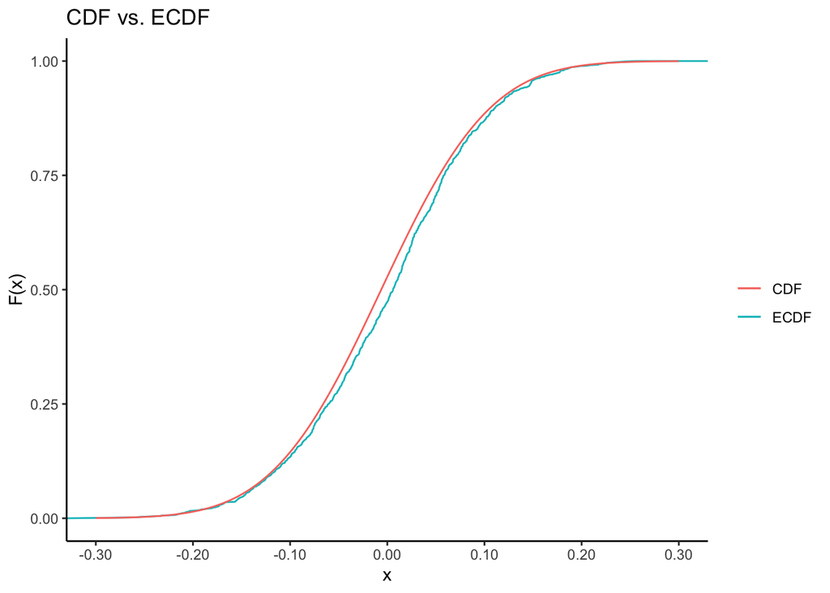

```r
ecdf_med <- NA
xs <- seq(-.3,.3,length.out=1000)

for(i in 1:1000) {
  data = rnorm(200)
  ecdf_med[i] = median(data)
}
df4 <- data.frame(ecdf=ecdf_med, cdf=porder(xs, 200, 100))

ggplot(df4) +
  stat_ecdf(aes(ecdf_med, col = "ECDF"), geom = "line") +
  geom_line(aes(x = xs, y=cdf, col = "CDF")) +
  scale_color_discrete(name = "", labels = c("CDF", "ECDF")) +
  scale_x_continuous(limits = c(-.3,.3), breaks = seq(-.3,.3,.1), labels = scales::comma) +
  labs(
    title = "CDF vs. ECDF",
    y = "F(x)",
    x = "x"
  ) +
  theme_classic()
```

The CDF and ECDF graphs above will condense as the number of samples increases. The ECDF will smooth out and mimic the CDF more accurately as the number of simulations increases.

## 1.5 Question 5

Using the simulated sampling distribution from the previous question, create a histogram (on the density scale). Overlay the histogram with a plot of the density function.

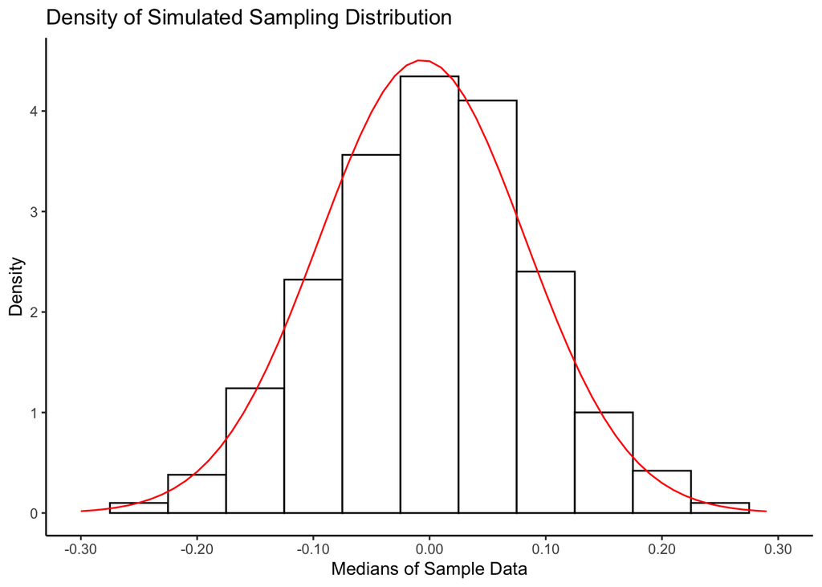

```r
ggplot() +
  geom_histogram(data = df4, aes(x = ecdf, y = ..density..), fill = "white", col= "black", binwidth = 0.05) +
  geom_line(data = df1, aes(x = x, y = dorder), col = "red") +
  theme_classic() +
  labs(title = "Density of Simulated Sampling Distribution",
       x = "Medians of Sample Data",
       y = "Density") +
  scale_x_continuous(limits = c(-.3,.3), breaks = seq(-.3,.3,.1), labels = scales::comma)
```

This is what I expected to see out of the density curve and histogram as it relates to the PDF of a normal distribution.

## 1.6 Question 6

Q: One very common way to compare a random sample to a theoretical candidate distribution is the QQ plot. It is created by ploting quantiles of the theoretical distribution on the x-axis and empirical quantiles from the sample on the y-axis.

If sample and theoretical quantiles come from the same distribution, then the plotted points will fall along the line y = x, approximately.

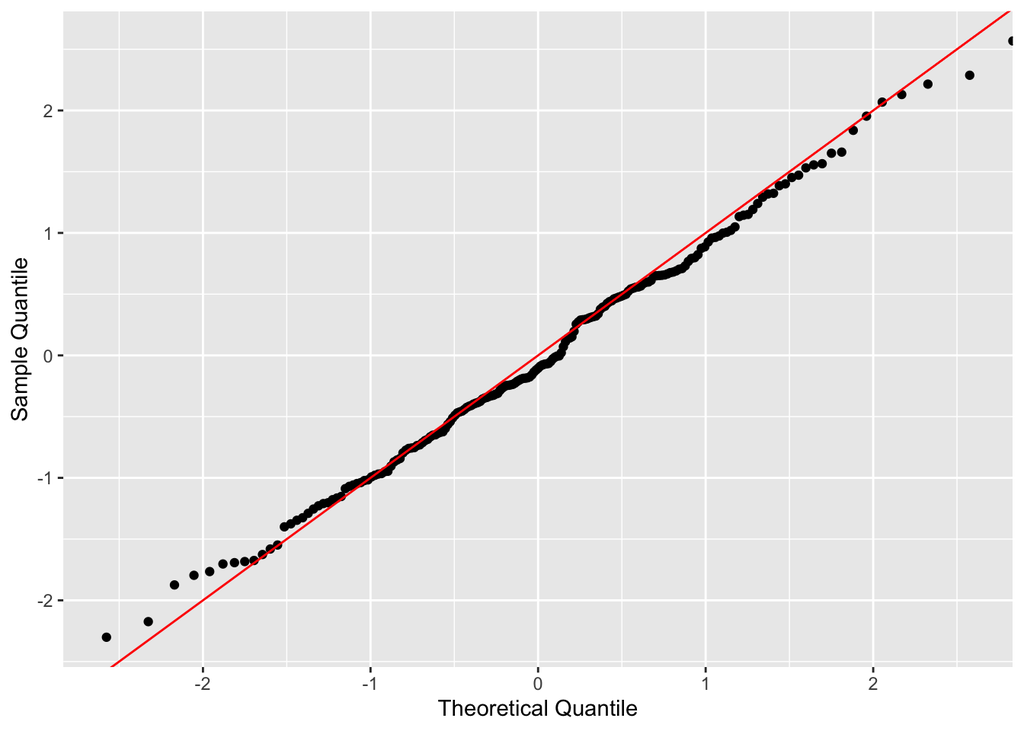

```r
random_sample <- rnorm(200) # random sample of numbers
candidate_dist <- qnorm # candidate distribution

theoretical_q <- candidate_dist((1:200)/200) # quantile function of all probabilities
sample_q <- quantile(random_sample, probs = (1:200)/200) # sample quantiles of random sample with all probabilities
df6 <- data.frame(theoretical_q=theoretical_q, sample_q=sample_q)

ggplot(df6) +
  geom_point(aes(x = theoretical_q, y = sample_q)) +
  geom_abline(slope = 1, col = "red") +
  labs(
    x = "Theoretical Quantile",
    y = "Sample Quantile"
  )
```

Q2: In the graph above you can see the points do indeed fall along the y=x line, especially around the x=0 value since that is where the most data points occur. As the go away from x=0, then there are less data points resulting in skewed data deviating from the y=x line.

For the assigment, generate a QQ plot for the simulated data of the median relative to the known sampling distribution of the median.

Does the simulated data agree with the theoretical sampling distribution?

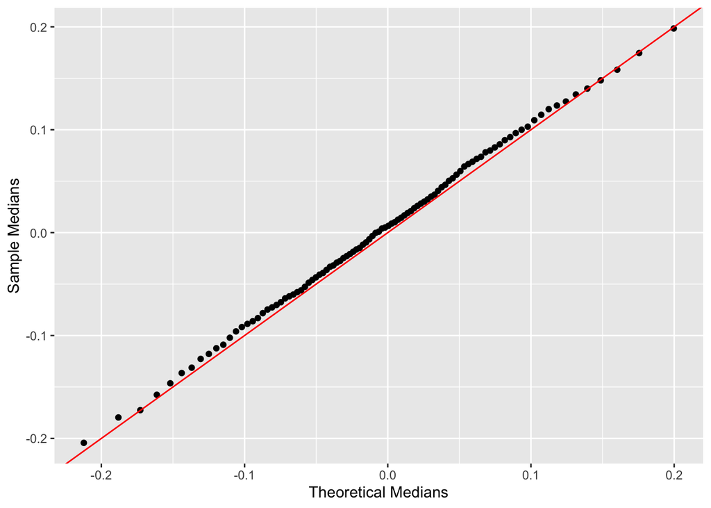

```r
# sampling normal distribution by simulation
N <- 200 # sample size
R <- 1000 # simulations
medians <- rep(NA, R) # vector for sample medians
for(i in 1:R) { # 1000 simulations
  medians[i] = median(rnorm(N)) # median of each sample
}

#compare quantiles from sim and analytic
quants_sample <- quantile(medians, probs = pvalues) # sample quantiles of probabilities
quants_analytic <- qorder(pvalues,n=200,k=100) #p,n,k

q6 <- data.frame(theoretical_medians = quants_analytic, sample_medians = quants_sample)

ggplot(q6) +
  geom_point(aes(x = theoretical_medians, y = sample_medians)) +
  geom_abline(slope = 1, col = "red") +
  labs(
    x = "Theoretical Medians",
    y = "Sample Medians"
  )
```

In the graph above, the theoretical and sample medians converge to the line of identity around 0. I believe this QQ Plot is very accurate as the even the deviations from the line of identity are miniscule when examining that the x and y axes are at such a small scale.

## 1.7 Question 7

Modify the dorder, porder, and qorder functions so that the functions take a new parameter k (for the kt**h order statistic) so that the functions will work for any order statistic and not just the median.

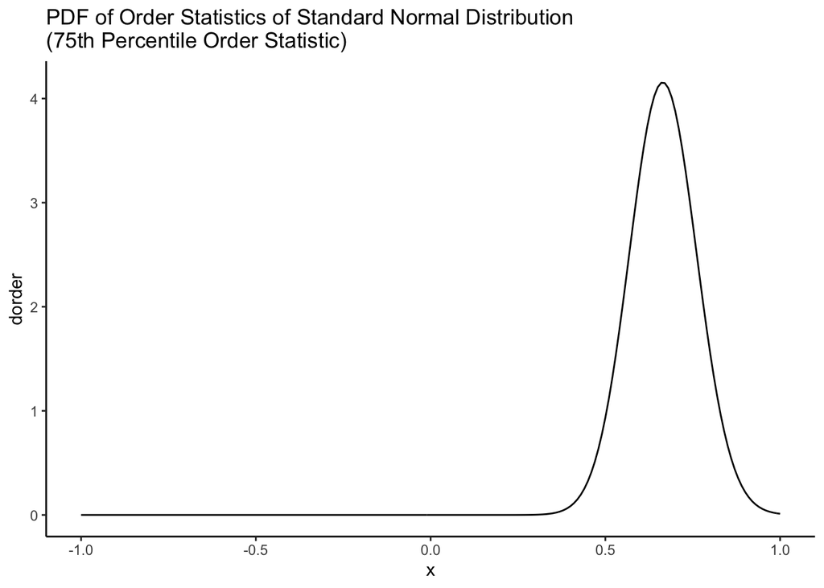

```r
df7d <- data.frame(x = xvalues, dorder = dorder(xvalues, 200,150)) # k=50 is the 25th percentile
ggplot(df7d, aes(x = x, y = dorder)) +
  geom_line() +
  theme_classic() +
  labs(title = "PDF of Order Statistics of Standard Normal Distribution
(75th Percentile Order Statistic)")
```

Adjusting the *k*<sup>*t**h*</sup> order statistic to the 75th percentile shifted the density of the normal distribution to the right.

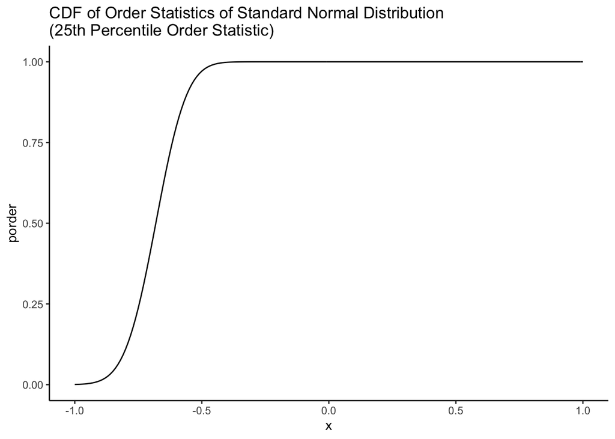

```r
df7p <- data.frame(x = xvalues, porder = porder(xvalues, 200,50))
ggplot(df7p, aes(x = x, y = porder)) +
  geom_line() +
  theme_classic() +
  labs(title = "CDF of Order Statistics of Standard Normal Distribution
(25th Percentile Order Statistic)")
```

Adjusting the *k*<sup>*t**h*</sup> order statistic to the 25th percentile shifted the probability of the normal distribution to the left.

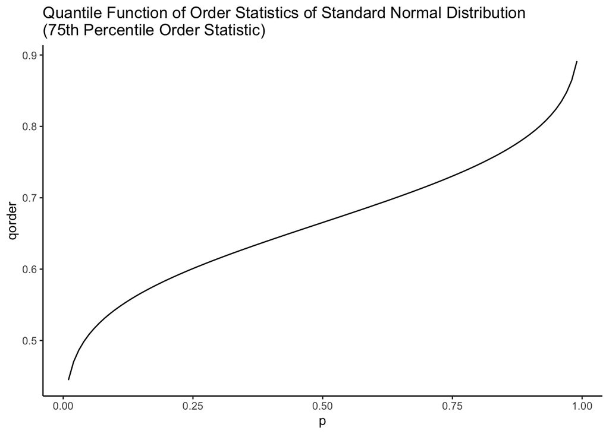

```r
df7q <- data.frame(p = pvalues, qorder = qorder(pvalues,200,150))
ggplot(df7q, aes(x = p, y = qorder)) +
  geom_line() +
  theme_classic() +
  labs(title = "Quantile Function of Order Statistics of Standard Normal Distribution
(75th Percentile Order Statistic)")
```

Adjusting the *k*<sup>*th*</sup> order statistic to the 75th percentile shifted the quantile of the normal distribution up.

## 1.8 Question 8

Generate the QQ plot for simulated data from the sampling distribution of the sample max and the theoretical largest order statistic distribution.

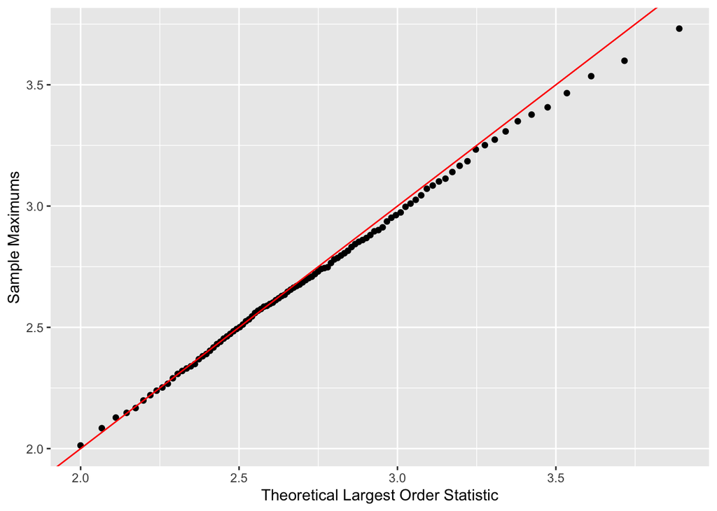

```r
# sampling normal distribution by simulation
maxs <- rep(NA, R) # vector for sample maxs
for(i in 1:R) { # 1000 simulations
  maxs[i] = max(rnorm(N)) # max of each sample
}

#compare quantiles from sim and analytic
max_sample <- quantile(maxs, probs = pvalues)
max_analytic <- qorder(pvalues,n=200,k=200) #p,n,k

q8 <- data.frame(theoretical_max = max_analytic, sample_max = max_sample)

ggplot(q8) +
  geom_point(aes(x = theoretical_max, y = sample_max)) +
  geom_abline(slope = 1, col = "red") +
  labs(
    x = "Theoretical Largest Order Statistic",
    y = "Sample Maximums"
  )
```

The QQ Plot above shows that the sample maximums and theoretical largest order statistic conver to the line of identity from about 2.25 to a little over 3.0. There is also a similarity among the x and y axes as the both measures fall within the same range.

## 1.9 Question 9

Modify the dorder, porder, and qorder functions so that the functions take new parameters dist and … so that the functions will work for any continuous distribution that has d and p functions defined in R.

```r
dorder_new <- function(x,k,n, dist="norm",...) { # default to normal distribution; (...) used to change mean or sd
  pf <- get(paste0("p", dist)) # create pnorm function for CDF
  df <- get(paste0("d", dist)) # create dnorm function for PDF

  # updated dorder function
  k*
  choose(n,k)*
  (pf(x,...))^(k-1)*
  (1-pf(x,...))^(n-k)*
  df(x,...)
}


porder_new <- function(x,n,k, dist="norm",...){
  pf <- get(paste0("p", dist))

  # updated porder function
  pbinom(k-1,
         n,
         pf(x,...),
         lower.tail = FALSE)
}

qorder_new <- function(p,n,k, dist="norm",...) {
  # updated qorder function
  out <- p
  for(i in seq_along(p)){
    out[i] <- uniroot(function(x) {porder_new(x,n,k, dist, ...) - p[i]}, c(-100,100))$root
  }
  out
}
```

## 1.10 Question 10

Use the newly modified functions to plot the probability and density functions for the sample min (N = 200).

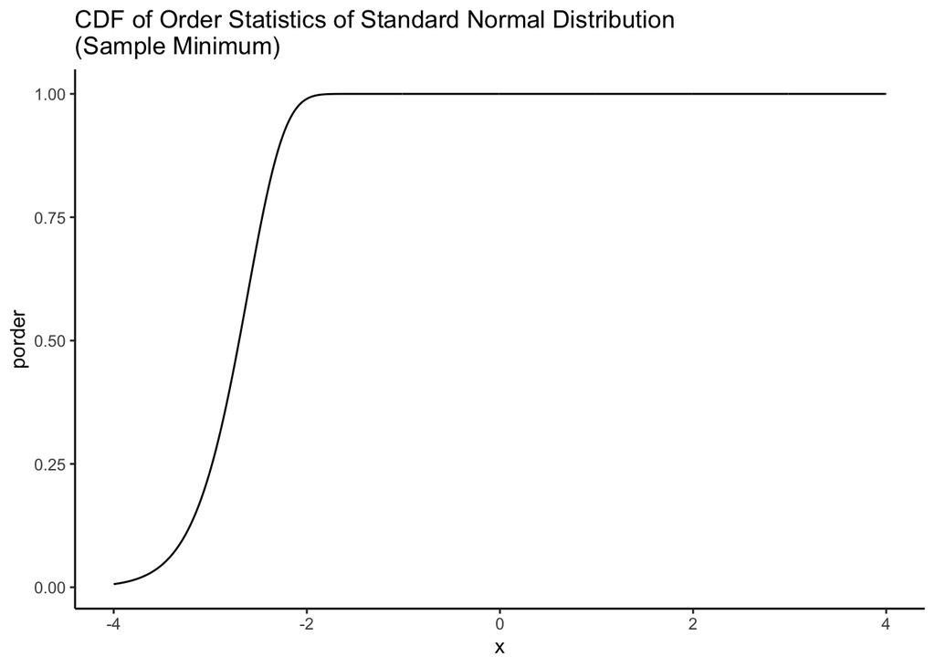

```r
xval = seq(-4, 4, .01)
df10p <- data.frame(x = xval, porder = porder_new(xval, n=200,k=1,dist="norm"))
ggplot(df10p, aes(x = x, y = porder)) +
  geom_line() +
  theme_classic() +
  labs(title = "CDF of Order Statistics of Standard Normal Distribution
(Sample Minimum)") +
  xlim(c(-4,4))
```

The probability of the sample minimum will be exactly 1 in a normal distribution.

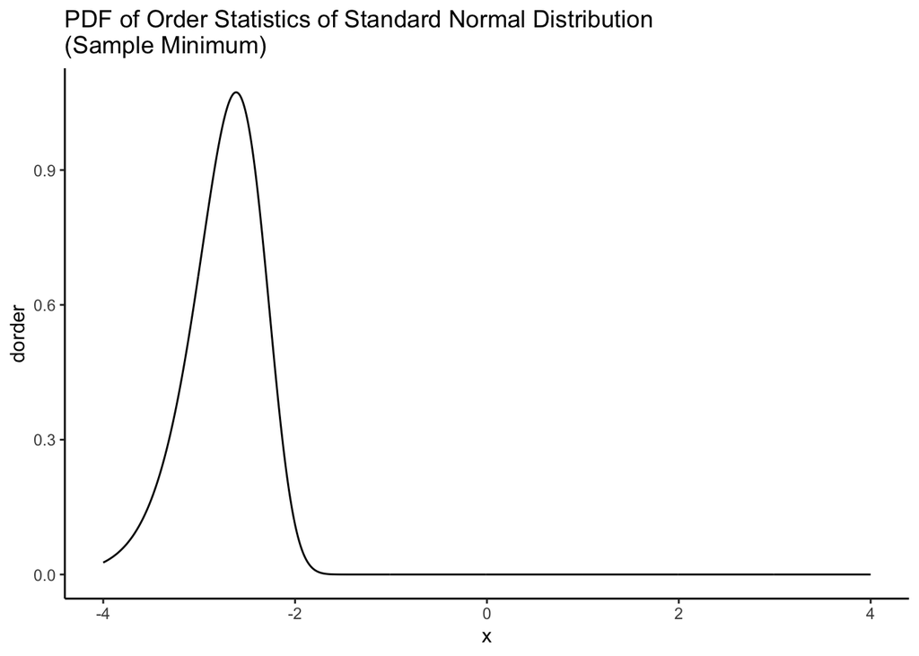

```r
df10d <- data.frame(x = xval, dorder = dorder_new(xval, n=200,k=1,dist="norm"))
ggplot(df10d, aes(x = x, y = dorder)) +
  geom_line() +
  theme_classic() +
  labs(title = "PDF of Order Statistics of Standard Normal Distribution
(Sample Minimum)") +
  xlim(c(-4,4))
```

# 2 Conclusions

The main takeaway from this deliverable is the affect of how changing input paramters of order statistics can drastically affect how the plot displays. Changing what the *k*<sup>*th*</sup> statistic is supposed to be skews the graph along the x-axis for the probability and density functions and along the y-axis for the quantile functions. I also learned how effective QQ Plots are when comparing two related values, in this case theoretical and sample data vectors.